# Análisis de Componentes Principales

Javier espinoza

2022-05-25

## Librerias usadas

```r
library(factoextra)
library(pheatmap)
library(readxl)
library(psych)
library(ggplot2)
library(vegan)
```

## Leer archivo

```r
peptideDescriptors <-read_excel("C:/Users/javeb/Documents/R/TESIS/Descriptores.xlsx")
peptideDescriptors$Tipo<-as.factor(peptideDescriptors$Tipo)
peptideDescriptors$Name <- as.factor(peptideDescriptors$Name)
summary(peptideDescriptors)
```

```
##       ...1            Name       sequence               Tipo
##  Min.   :  1.0   >AFP_1 :  1   Length:466         AFP     : 27
##  1st Qu.:117.2   >AFP_10:  1   Class :character   Antiox  :123
##  Median :233.5   >AFP_11:  1   Mode  :character   Antipara:101
##  Mean   :233.5   >AFP_12:  1                      CAP     :  3
##  3rd Qu.:349.8   >AFP_13:  1                      CPP     :150
##  Max.   :466.0   >AFP_14:  1                      CSP-EX  : 24
##                  (Other):460                      Insect  : 38
##      aIndex           Boman            Charge             PP1
##  Min.   :  0.00   Min.   :-3.205   Min.   :-7.0470   Min.   :-0.93333
##  1st Qu.: 38.81   1st Qu.: 0.076   1st Qu.:-0.0582   1st Qu.:-0.35587
##  Median : 72.50   Median : 1.393   Median : 1.9400   Median :-0.16502
##  Mean   : 80.56   Mean   : 1.568   Mean   : 2.5539   Mean   :-0.14885
##  3rd Qu.:113.75   3rd Qu.: 2.973   3rd Qu.: 4.9396   3rd Qu.: 0.06288
##  Max.   :292.50   Max.   : 9.578   Max.   :23.9352   Max.   : 0.72200
##
##       PP2               PP3                 F1                   F2
##  Min.   :-0.8400   Min.   :-0.58083   Min.   :-1.3503333   Min.   :-1.52450
##  1st Qu.:-0.3748   1st Qu.: 0.05558   1st Qu.:-0.3507159   1st Qu.:-0.27754
##  Median :-0.2595   Median : 0.15722   Median :-0.1683089   Median : 0.05994
##  Mean   :-0.2103   Mean   : 0.13123   Mean   :-0.1741883   Mean   : 0.01531
##  3rd Qu.:-0.0737   3rd Qu.: 0.25777   3rd Qu.:-0.0001154   3rd Qu.: 0.34459
##  Max.   : 0.7944   Max.   : 0.72545   Max.   : 0.8100000   Max.   : 1.09789
##
##        F3                 F4                 F5                  F6
##  Min.   :-1.22467   Min.   :-0.78667   Min.   :-0.677250   Min.   :-1.20275
##  1st Qu.:-0.31215   1st Qu.:-0.05731   1st Qu.:-0.175408   1st Qu.:-0.15448
##  Median :-0.09078   Median : 0.32674   Median :-0.007648   Median : 0.04642
##  Mean   :-0.04197   Mean   : 0.32373   Mean   : 0.112325   Mean   : 0.09522
##  3rd Qu.: 0.23388   3rd Qu.: 0.66357   3rd Qu.: 0.237694   3rd Qu.: 0.33351
##  Max.   : 1.40100   Max.   : 1.39913   Max.   : 2.294667   Max.   : 1.65727
##
##  Hidrophobicity           pI               MW
##  Min.   :-1.09500   Min.   : 3.167   Min.   :  217.2
##  1st Qu.:-0.13154   1st Qu.: 6.409   1st Qu.: 1066.5
##  Median : 0.04023   Median : 9.700   Median : 2033.5
##  Mean   : 0.07271   Mean   : 9.063   Mean   : 2385.1
##  3rd Qu.: 0.28987   3rd Qu.:11.473   3rd Qu.: 3050.7
##  Max.   : 1.36364   Max.   :13.454   Max.   :13992.9
##
```

## Histogramas por descriptor

# Descriptores

aIndex = Indice alifatico

Boman = indice de interacción potencial de proteinas de Boman

Charge = Carga neta de una secuencia proteica

# Propiedades de Cruciani

PP1 = Polaridad

PP2 = Hidrofobicidad

PP3 = Union de hidrogeno

# Vectores de Fasgai

F1 = Hidrofobicidad

F2 = propensidad de giro y alfa

F3 = propiedades “Bulky”

F4 = Indice de caracteristicas composicionales

F5 = Flexibilidad local

F6 = Propiedades electronicas

Hidrophobicity = hidrofobicidad

pI = punto isoelectrico

MW = Peso molecular

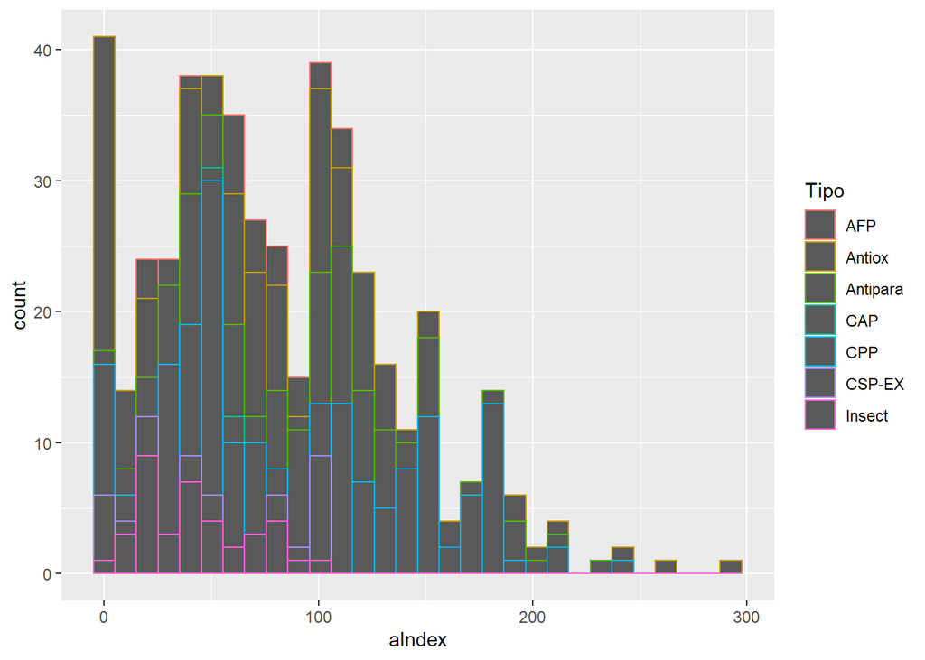

```r
ggplot(peptideDescriptors, aes(x = aIndex, color = Tipo)) + geom_histogram()
```

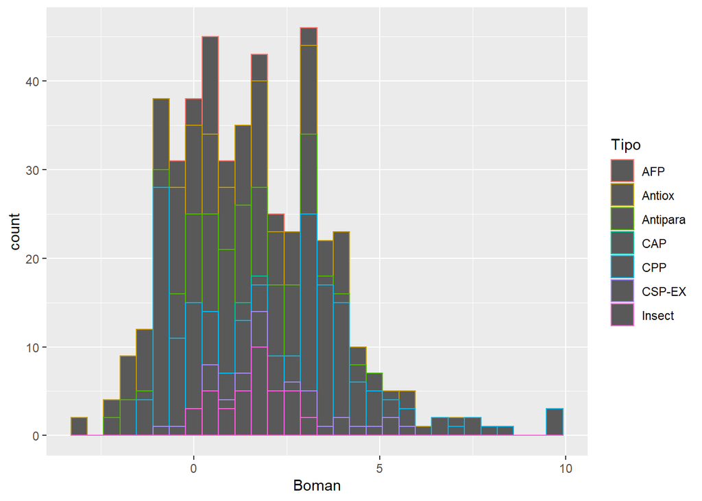

```r
ggplot(peptideDescriptors, aes(x = Boman, color = Tipo)) + geom_histogram()
```

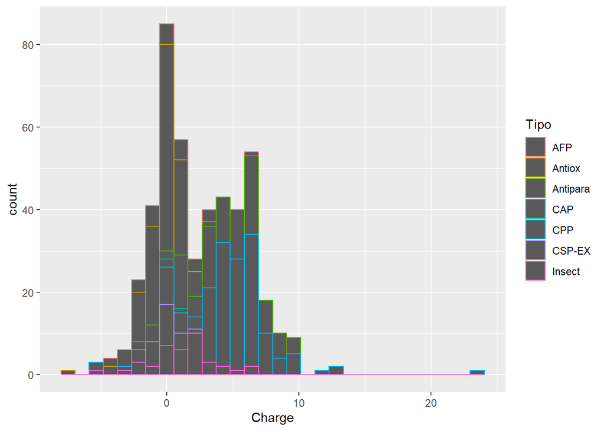

```r
ggplot(peptideDescriptors, aes(x = Charge, color = Tipo)) + geom_histogram()
```

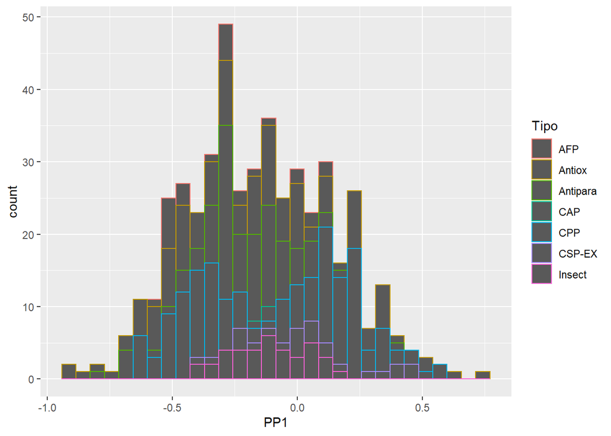

```r
ggplot(peptideDescriptors, aes(x = PP1, color = Tipo)) + geom_histogram()
```

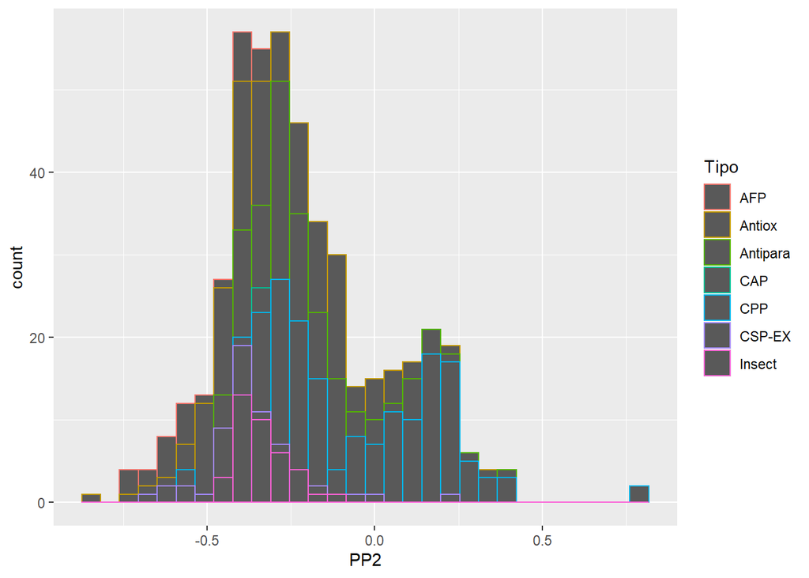

```r
ggplot(peptideDescriptors, aes(x = PP2, color = Tipo)) + geom_histogram()
```

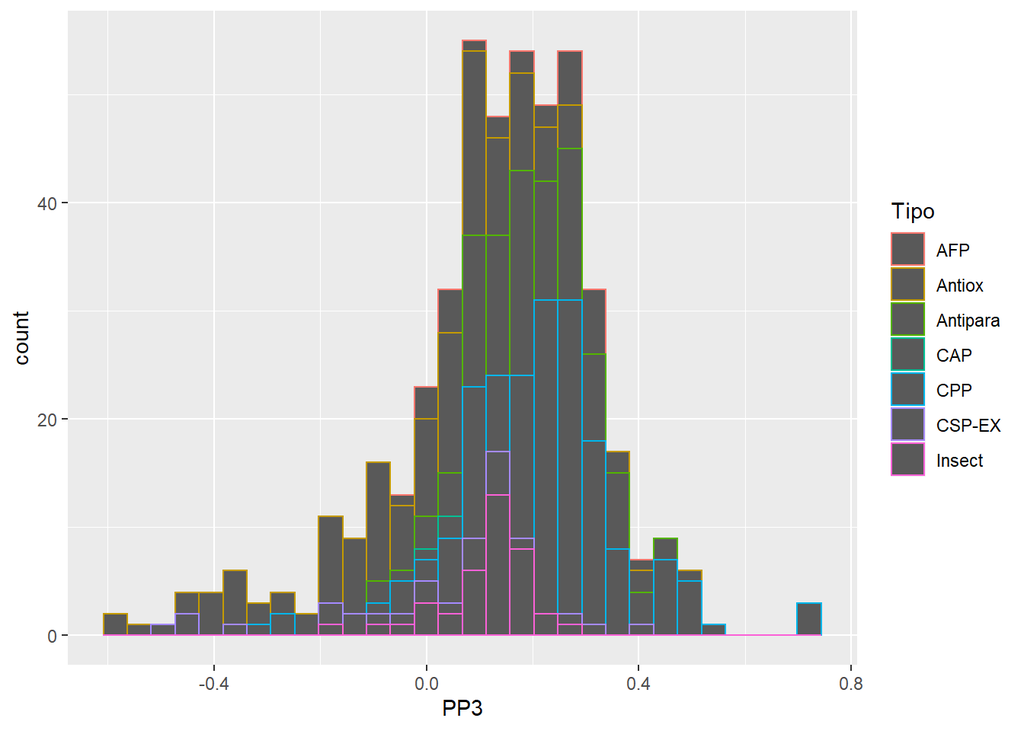

```r
ggplot(peptideDescriptors, aes(x = PP3, color = Tipo)) + geom_histogram()
```

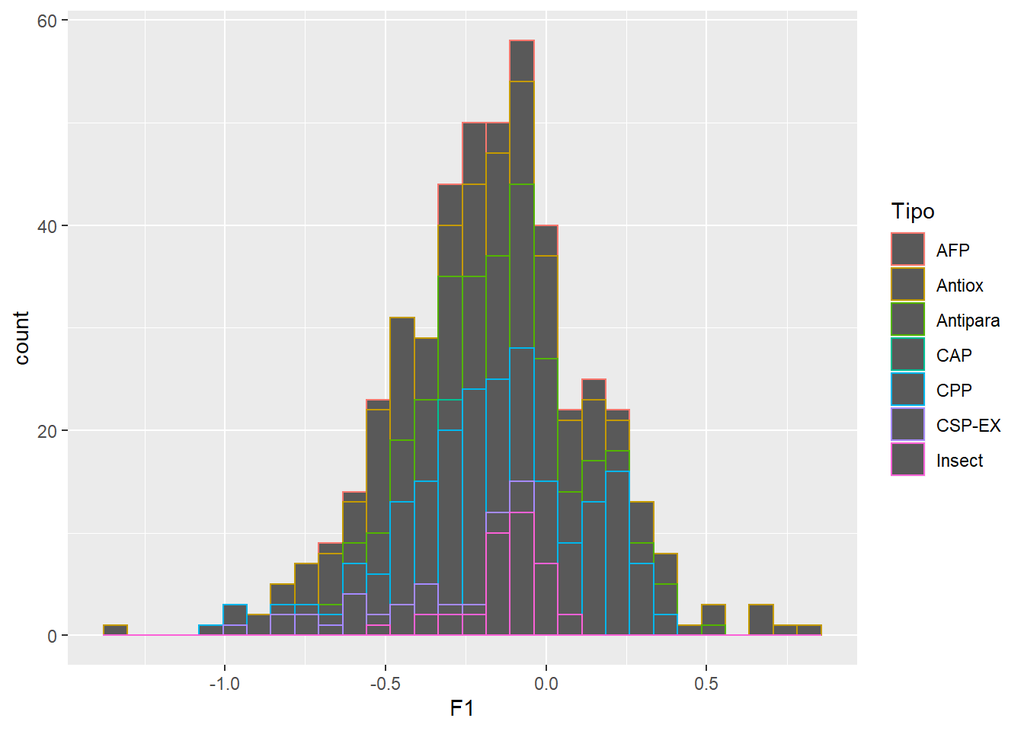

```r
ggplot(peptideDescriptors, aes(x = F1, color = Tipo)) + geom_histogram()
```

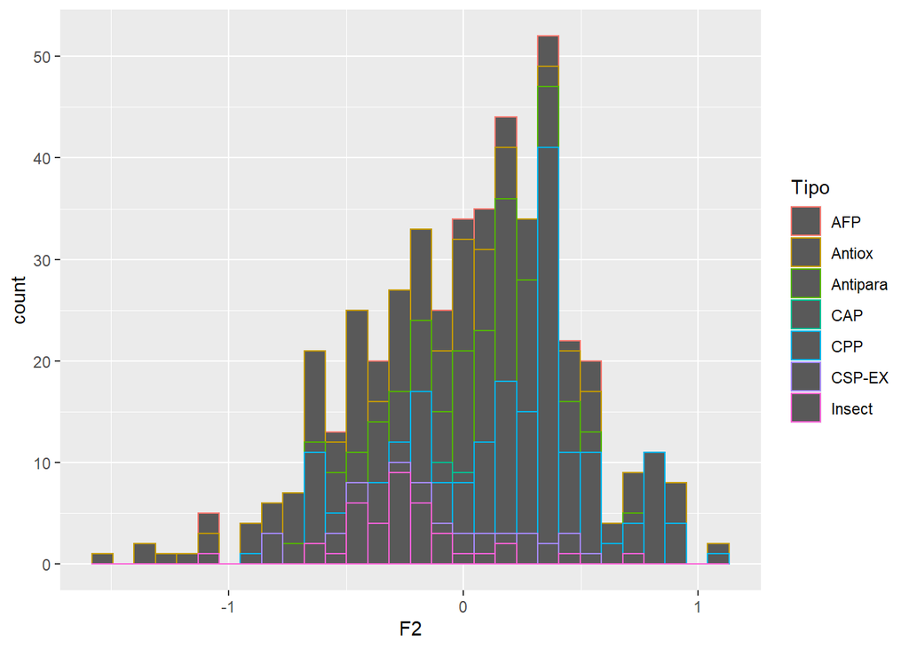

```r
ggplot(peptideDescriptors, aes(x = F2, color = Tipo)) + geom_histogram()
```

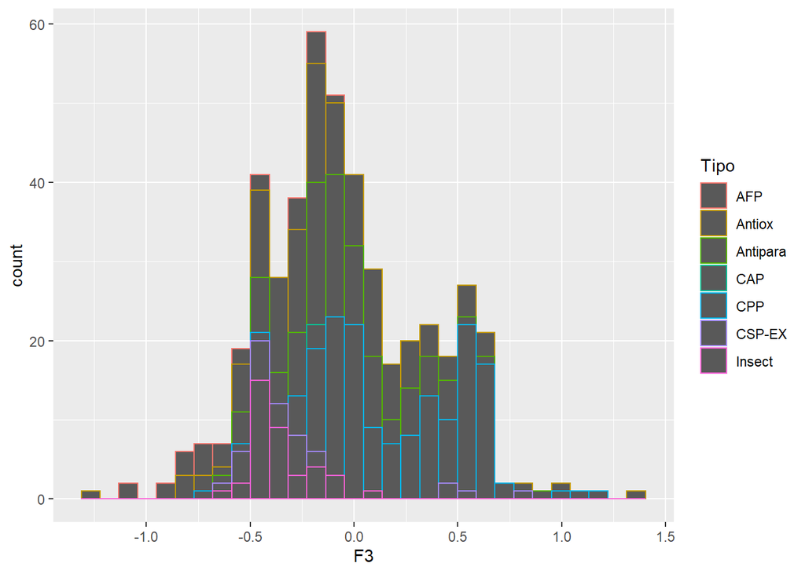

```r
ggplot(peptideDescriptors, aes(x = F3, color = Tipo)) + geom_histogram()
```

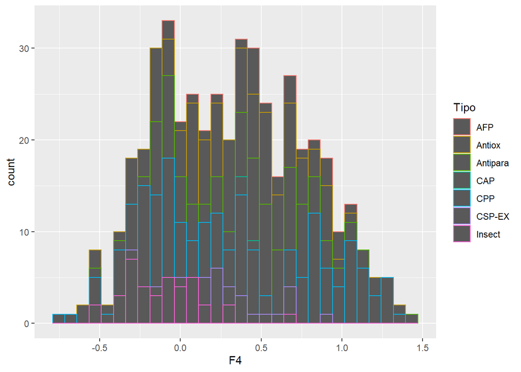

```r
ggplot(peptideDescriptors, aes(x = F4, color = Tipo)) + geom_histogram()
```

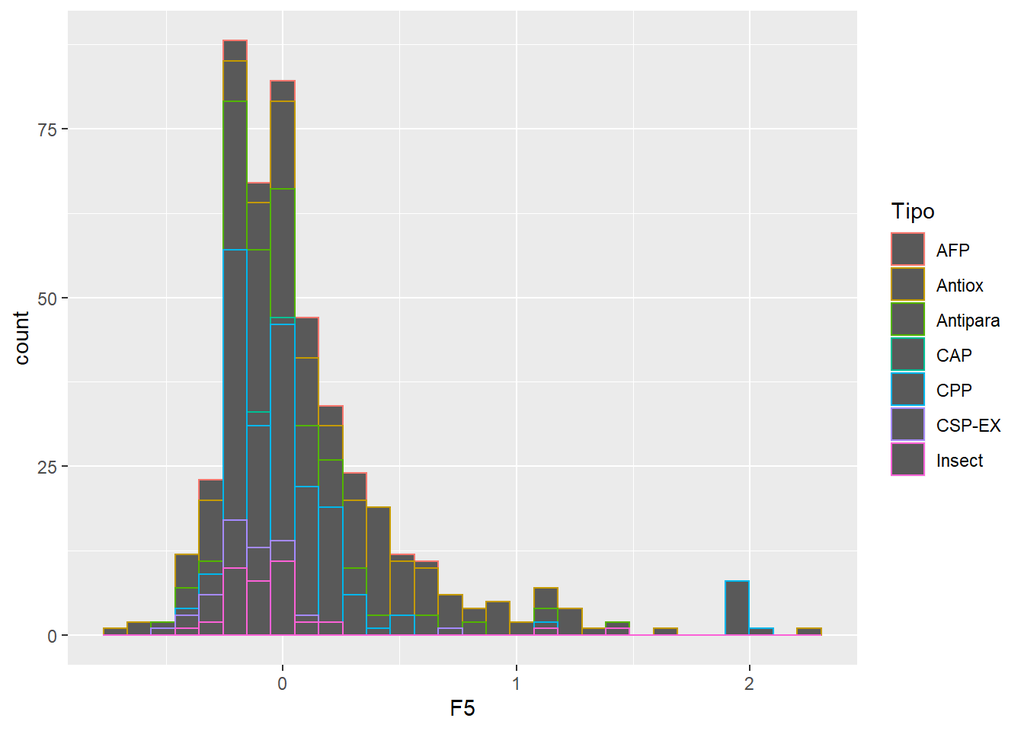

```r
ggplot(peptideDescriptors, aes(x = F5, color = Tipo)) + geom_histogram()
```

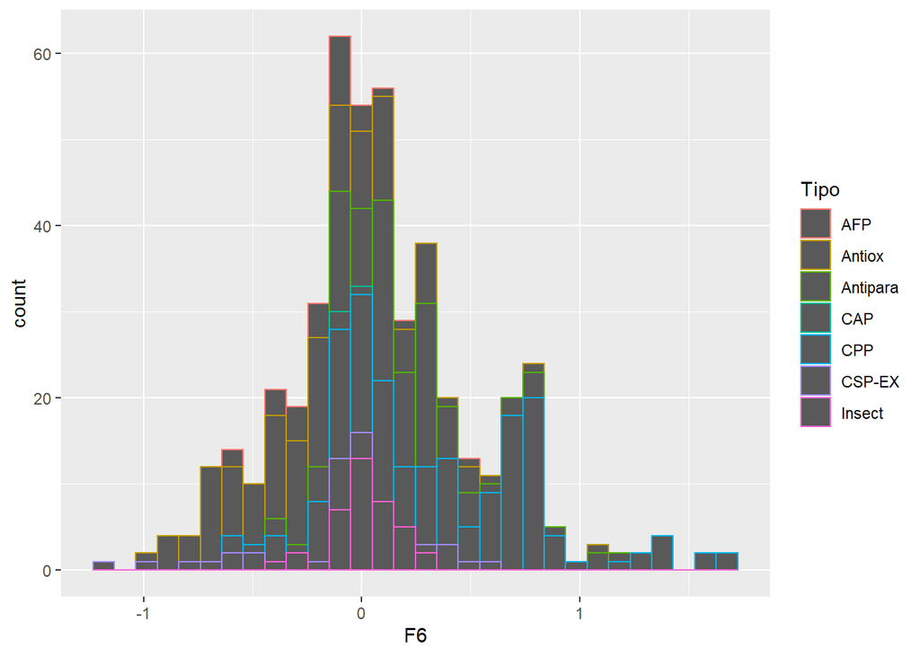

```r
ggplot(peptideDescriptors, aes(x = F6, color = Tipo)) + geom_histogram()
```

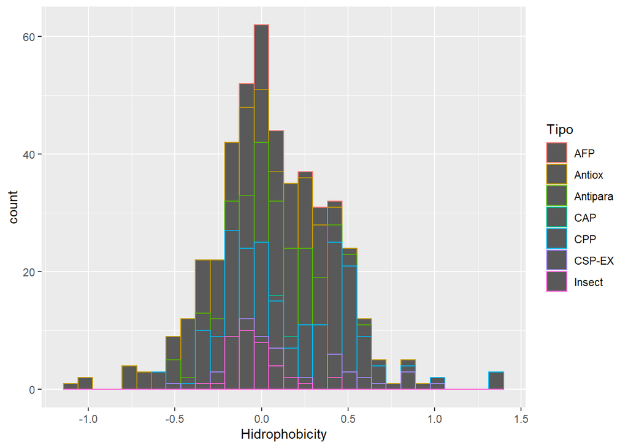

```r
ggplot(peptideDescriptors, aes(x = Hidrophobicity, color = Tipo)) + geom_histogram()
```

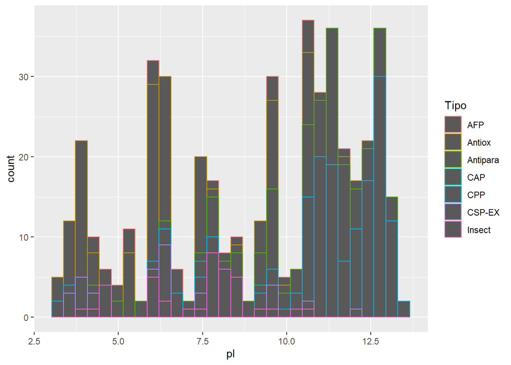

```r
ggplot(peptideDescriptors, aes(x = pI, color = Tipo)) + geom_histogram()
```

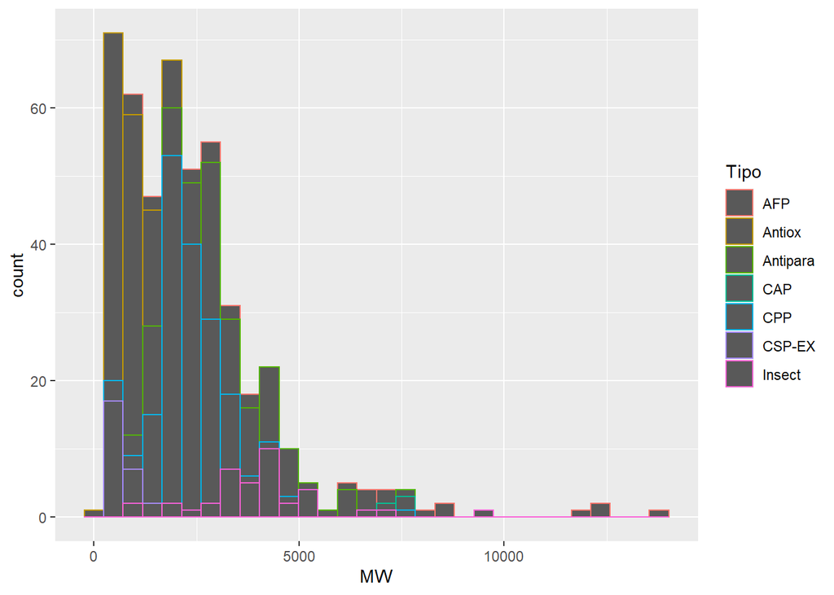

```r
ggplot(peptideDescriptors, aes(x = MW, color = Tipo)) + geom_histogram()
```

## Boxplot por descriptor

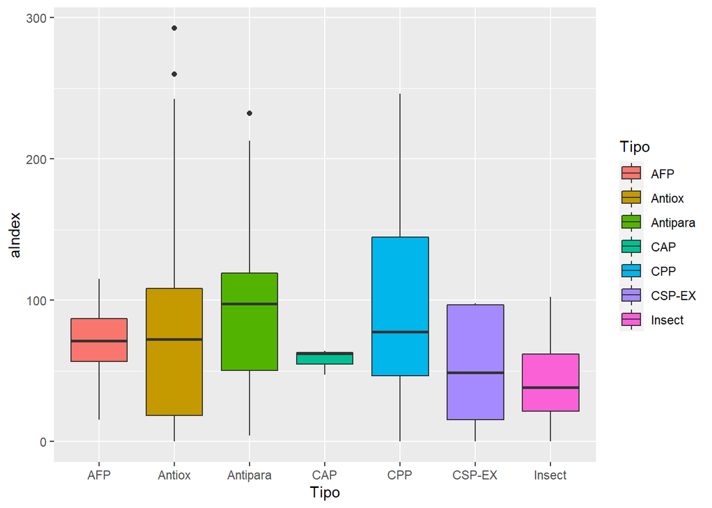

```r
ggplot(peptideDescriptors, aes(x=Tipo, y=aIndex, fill=Tipo)) + geom_boxplot()
```

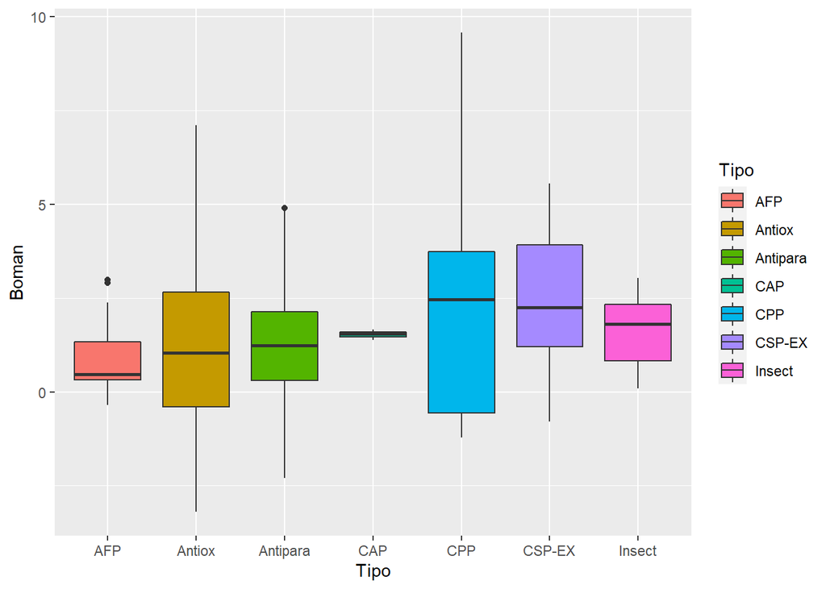

```r
ggplot(peptideDescriptors, aes(x=Tipo, y=Boman, fill=Tipo)) + geom_boxplot()
```

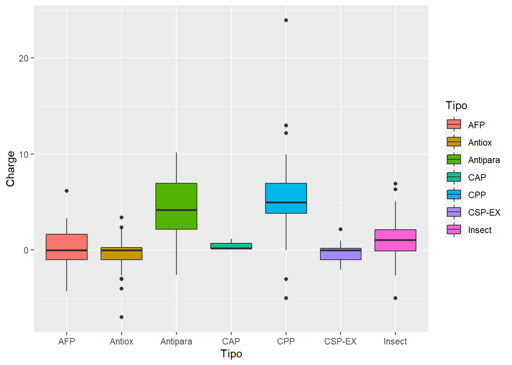

```r
ggplot(peptideDescriptors, aes(x=Tipo, y=Charge, fill=Tipo)) + geom_boxplot()
```

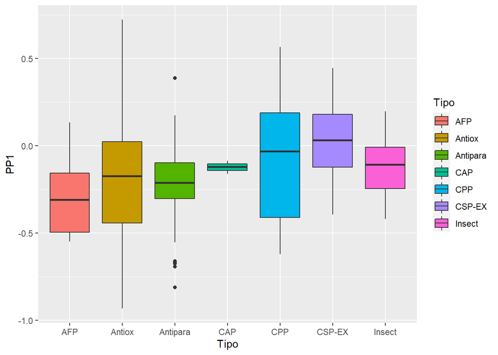

```r
ggplot(peptideDescriptors, aes(x=Tipo, y=PP1, fill=Tipo)) + geom_boxplot()
```

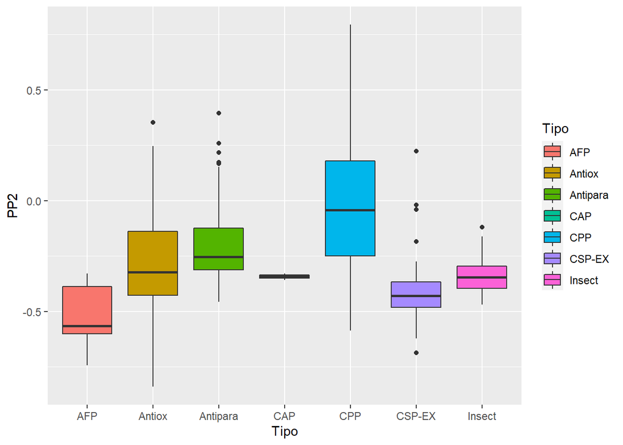

```r
ggplot(peptideDescriptors, aes(x=Tipo, y=PP2, fill=Tipo)) + geom_boxplot()
```

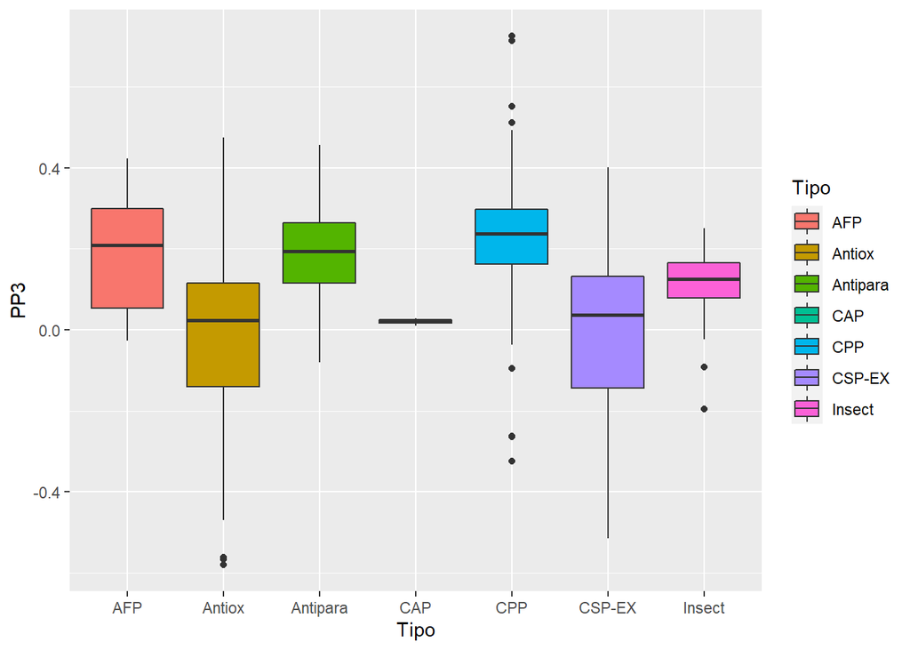

```r
ggplot(peptideDescriptors, aes(x=Tipo, y=PP3, fill=Tipo)) + geom_boxplot()
```

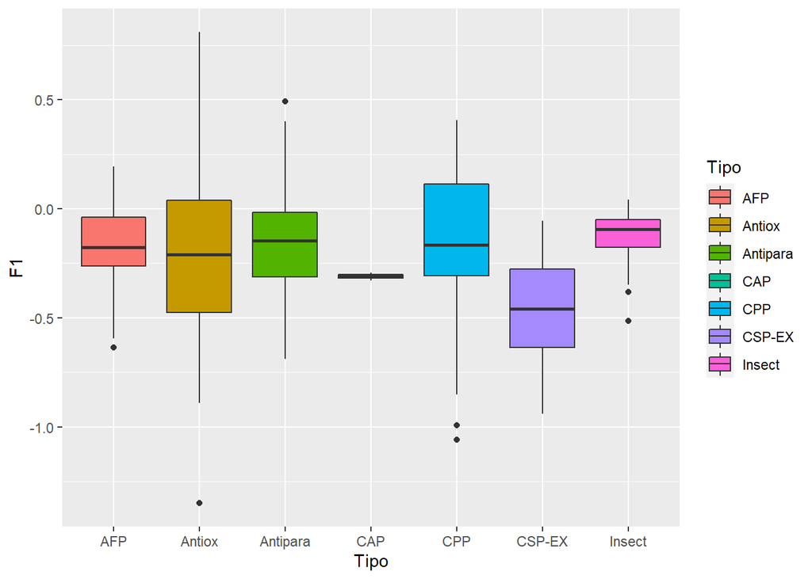

```r
ggplot(peptideDescriptors, aes(x=Tipo, y=F1, fill=Tipo)) + geom_boxplot()
```

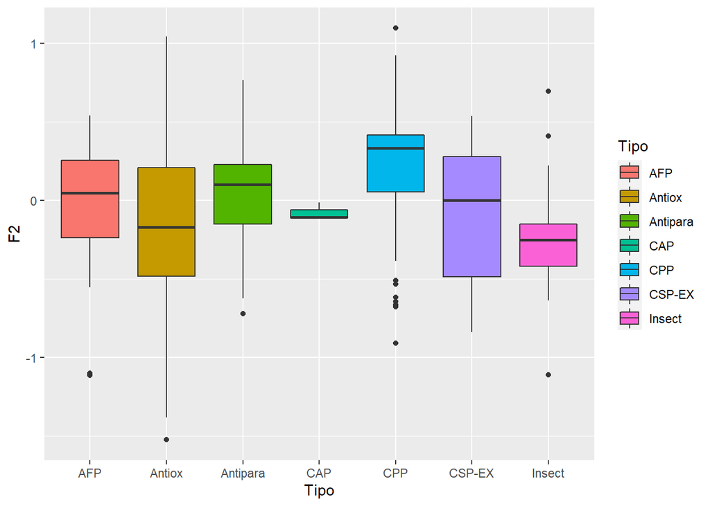

```r
ggplot(peptideDescriptors, aes(x=Tipo, y=F2, fill=Tipo)) + geom_boxplot()
```

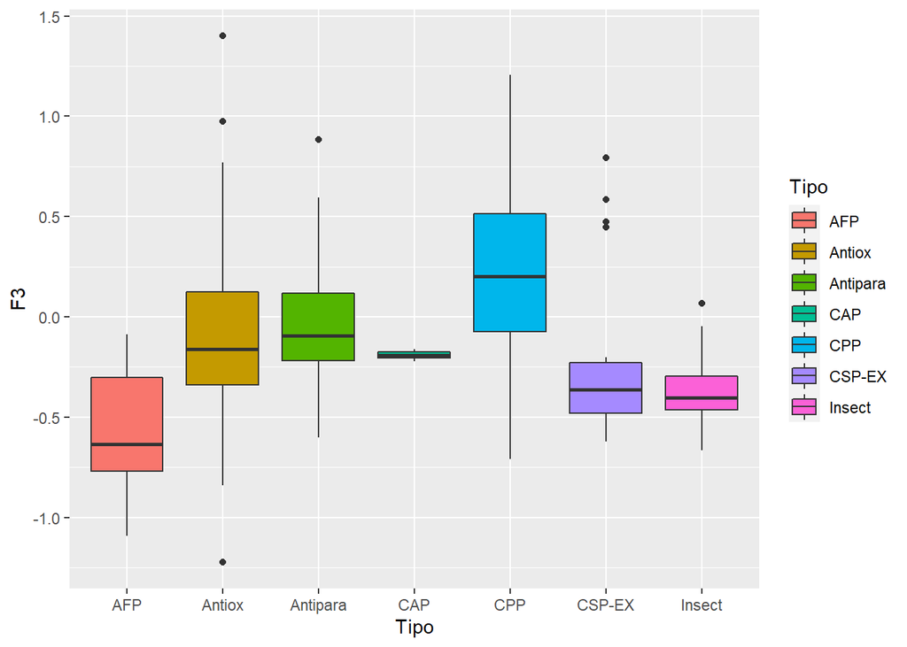

```r
ggplot(peptideDescriptors, aes(x=Tipo, y=F3, fill=Tipo)) + geom_boxplot()
```

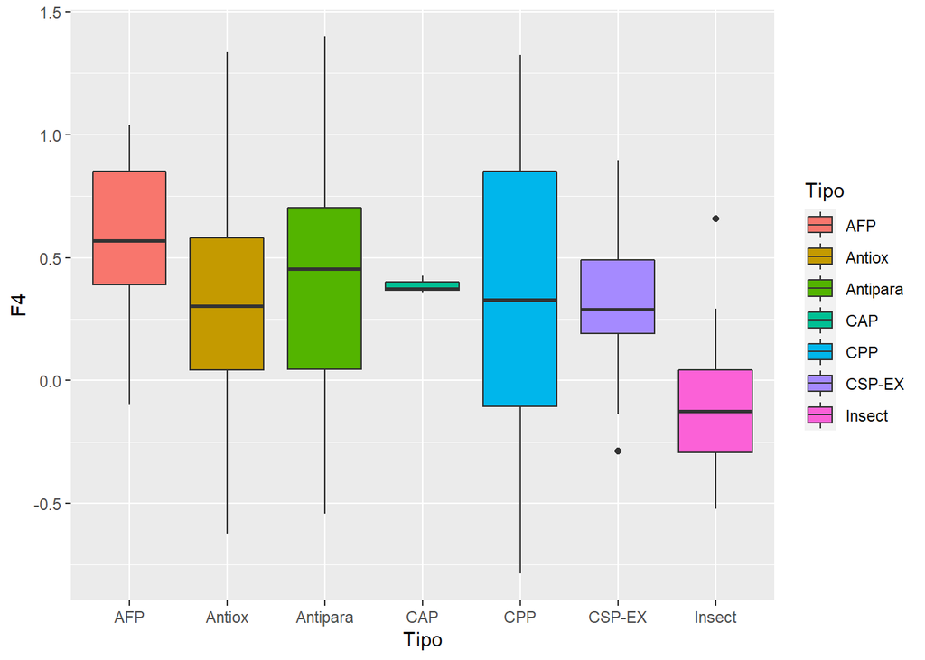

```r
ggplot(peptideDescriptors, aes(x=Tipo, y=F4, fill=Tipo)) + geom_boxplot()
```

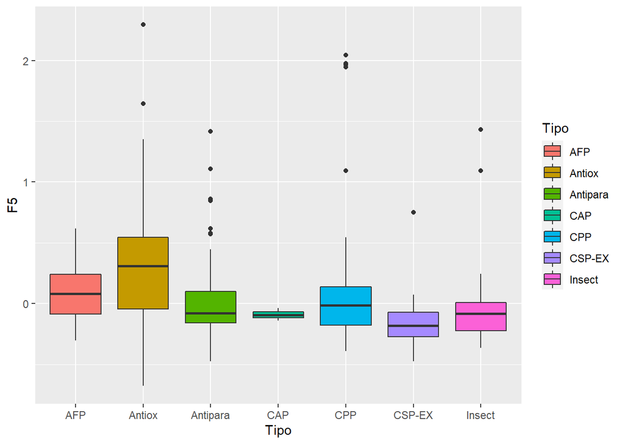

```r
ggplot(peptideDescriptors, aes(x=Tipo, y=F5, fill=Tipo)) + geom_boxplot()
```

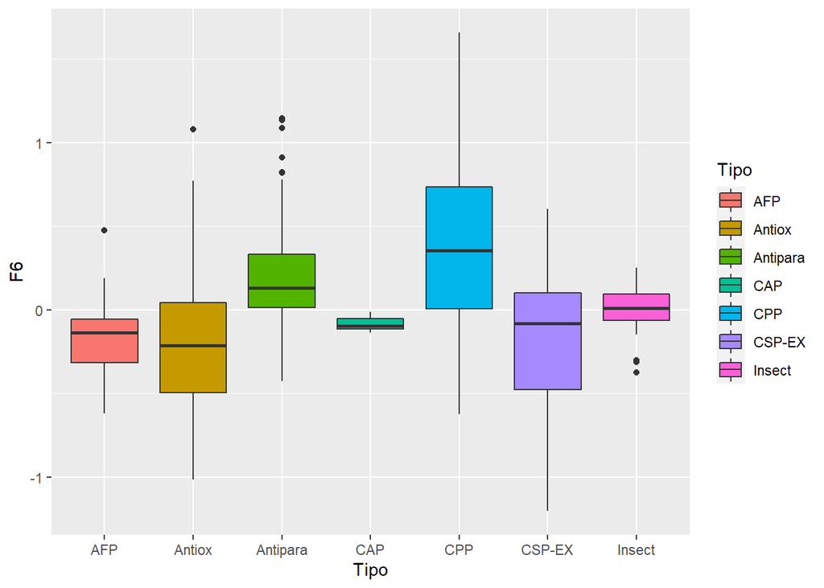

```r
ggplot(peptideDescriptors, aes(x=Tipo, y=F6, fill=Tipo)) + geom_boxplot()
```

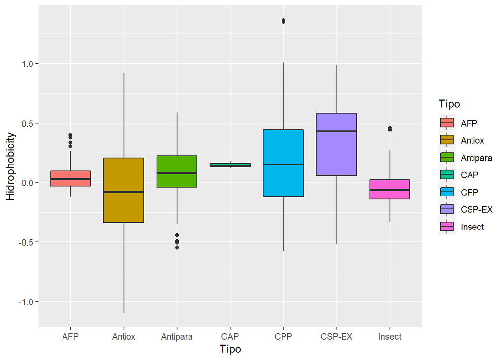

```r
ggplot(peptideDescriptors, aes(x=Tipo, y=Hidrophobicity, fill=Tipo)) + geom_boxplot()
```

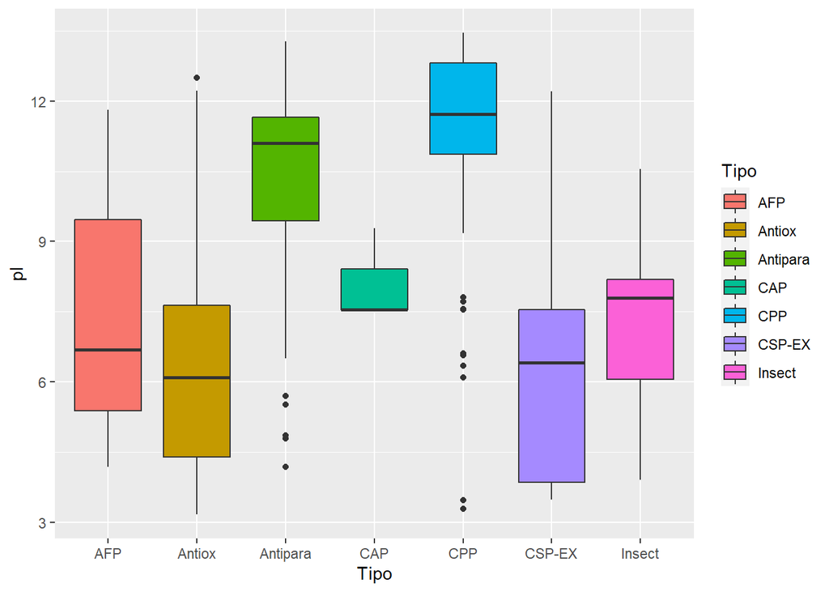

```r
ggplot(peptideDescriptors, aes(x=Tipo, y=pI, fill=Tipo)) + geom_boxplot()
```

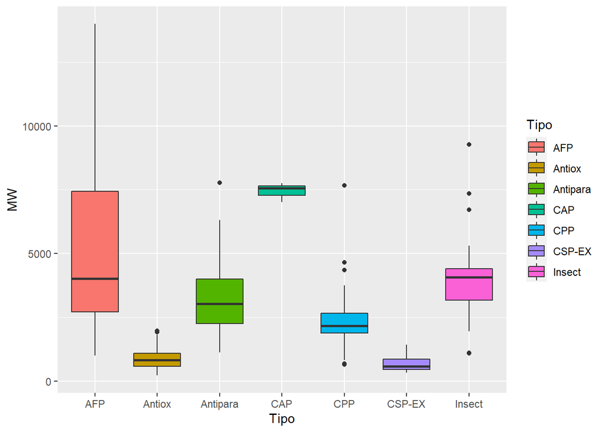

```r
ggplot(peptideDescriptors, aes(x=Tipo, y=MW, fill=Tipo)) + geom_boxplot()
```

# Evaluación

Al observar los histogramas y boxplots podemos determinar que existen valores atipicos, en los descriptores de Indice alifatico, carga, hidrofobicidad de las propiedades de cruciani. Y en especial en peso molecular.

Estos valores pueden deverse a la variacion de cada peptido, su composicion y extención, sin embargo estos valores seran tomados en cuenta para los proximos análisis y futura seleccion de descriptores.

# Escalamiento

```r
Descriptors= subset(peptideDescriptors, select = -c(Name, sequence, Tipo))
pepscale = scale(Descriptors)
summary(pepscale)
```

```
##       ...1             aIndex            Boman              Charge
##  Min.   :-1.7265   Min.   :-1.4583   Min.   :-2.31097   Min.   :-2.7657
##  1st Qu.:-0.8632   1st Qu.:-0.7558   1st Qu.:-0.72243   1st Qu.:-0.7525
##  Median : 0.0000   Median :-0.1460   Median :-0.08487   Median :-0.1769
##  Mean   : 0.0000   Mean   : 0.0000   Mean   : 0.00000   Mean   : 0.0000
##  3rd Qu.: 0.8632   3rd Qu.: 0.6007   3rd Qu.: 0.67995   3rd Qu.: 0.6872
##  Max.   : 1.7265   Max.   : 3.8363   Max.   : 3.87818   Max.   : 6.1592
##       PP1                PP2               PP3                F1
##  Min.   :-2.69497   Min.   :-2.5631   Min.   :-3.6346   Min.   :-3.95262
##  1st Qu.:-0.71119   1st Qu.:-0.6696   1st Qu.:-0.3861   1st Qu.:-0.59325
##  Median :-0.05552   Median :-0.2005   Median : 0.1327   Median : 0.01976
##  Mean   : 0.00000   Mean   : 0.0000   Mean   : 0.0000   Mean   : 0.00000
##  3rd Qu.: 0.72739   3rd Qu.: 0.5558   3rd Qu.: 0.6459   3rd Qu.: 0.58500
##  Max.   : 2.99169   Max.   : 4.0891   Max.   : 3.0331   Max.   : 3.30752
##        F2                 F3                F4                  F5
##  Min.   :-3.43703   Min.   :-2.9946   Min.   :-2.464961   Min.   :-1.7494
##  1st Qu.:-0.65367   1st Qu.:-0.6841   1st Qu.:-0.845863   1st Qu.:-0.6375
##  Median : 0.09963   Median :-0.1236   Median : 0.006682   Median :-0.2658
##  Mean   : 0.00000   Mean   : 0.0000   Mean   : 0.000000   Mean   : 0.0000
##  3rd Qu.: 0.73500   3rd Qu.: 0.6984   3rd Qu.: 0.754396   3rd Qu.: 0.2778
##  Max.   : 2.41645   Max.   : 3.6536   Max.   : 2.387261   Max.   : 4.8353
##        F6          Hidrophobicity           pI                MW
##  Min.   :-2.8446   Min.   :-3.43180   Min.   :-1.9840   Min.   :-1.1639
##  1st Qu.:-0.5472   1st Qu.:-0.60027   1st Qu.:-0.8931   1st Qu.:-0.7079
##  Median :-0.1069   Median :-0.09544   Median : 0.2144   Median :-0.1887
##  Mean   : 0.0000   Mean   : 0.00000   Mean   : 0.0000   Mean   : 0.0000
##  3rd Qu.: 0.5222   3rd Qu.: 0.63823   3rd Qu.: 0.8109   3rd Qu.: 0.3574
##  Max.   : 3.4233   Max.   : 3.79394   Max.   : 1.4776   Max.   : 6.2319
```

## Calculo de componentes principales y visualización

```r
PCApep = prcomp(pepscale)
summary(PCApep)
```

```
## Importance of components:
##                           PC1    PC2    PC3    PC4     PC5     PC6     PC7
## Standard deviation     2.3599 1.8744 1.3356 1.1866 1.04417 0.89956 0.79448
## Proportion of Variance 0.3481 0.2196 0.1115 0.0880 0.06814 0.05058 0.03945
## Cumulative Proportion  0.3481 0.5677 0.6791 0.7671 0.83529 0.88587 0.92532
##                            PC8     PC9   PC10    PC11    PC12    PC13    PC14
## Standard deviation     0.56376 0.51293 0.4595 0.37879 0.33798 0.27539 0.20088
## Proportion of Variance 0.01986 0.01644 0.0132 0.00897 0.00714 0.00474 0.00252
## Cumulative Proportion  0.94518 0.96162 0.9748 0.98379 0.99093 0.99567 0.99819
##                           PC15    PC16
## Standard deviation     0.14570 0.08778
## Proportion of Variance 0.00133 0.00048
## Cumulative Proportion  0.99952 1.00000
```

## Para escoger el numero de PCAs

```r
stdev= PCApep$sdev
pr_var = stdev^2
pr_var[1:15]
```

```
##  [1] 5.56915088 3.51339495 1.78375612 1.40807708 1.09028119 0.80920501
##  [7] 0.63120560 0.31782099 0.26309743 0.21116629 0.14348525 0.11423165
## [13] 0.07583882 0.04035457 0.02122915
```

```r
prop_varex =pr_var/sum(pr_var)
prop_varex[1:15]
```

```
##  [1] 0.348071930 0.219587184 0.111484757 0.088004817 0.068142575 0.050575313
##  [7] 0.039450350 0.019863812 0.016443589 0.013197893 0.008967828 0.007139478
## [13] 0.004739926 0.002522161 0.001326822
```

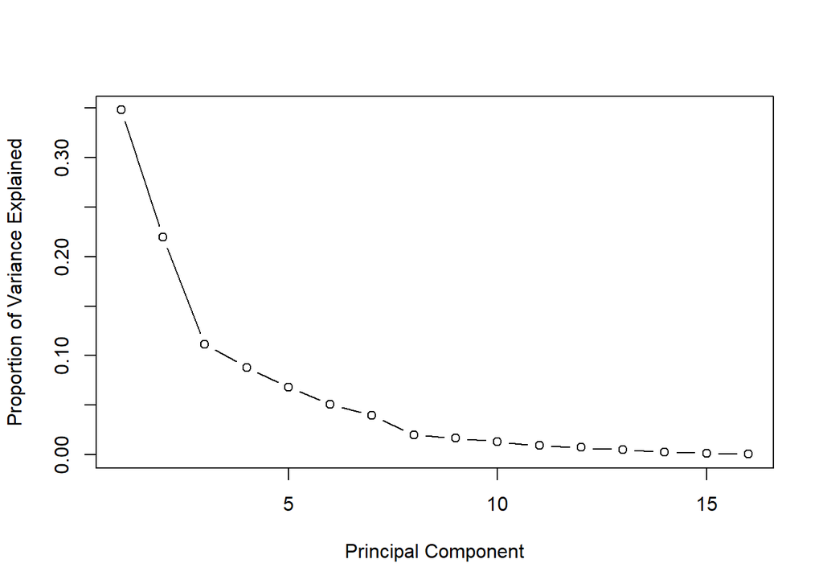

```r
plot(prop_varex, xlab = "Principal Component",ylab = "Proportion of Variance Explained",type = "b")
```

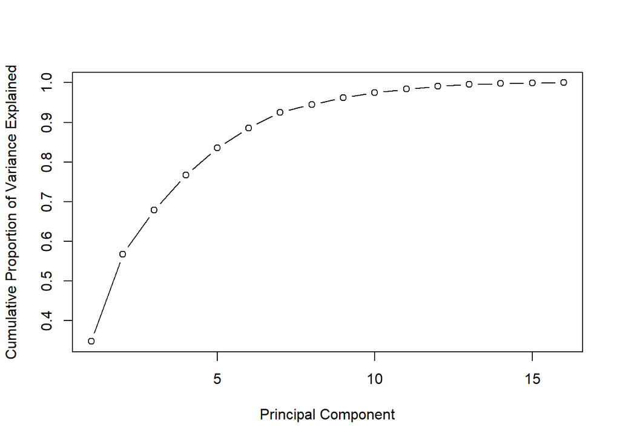

```r
plot(cumsum(prop_varex), xlab = "Principal Component",ylab = "Cumulative Proportion of Variance Explained",type = "b")
```

## Se determina que los 5 primeros componentes principales seran usados para los calculos.

## Determinar numero optimo de clusters por medio del metodo de “avarage silhouette”

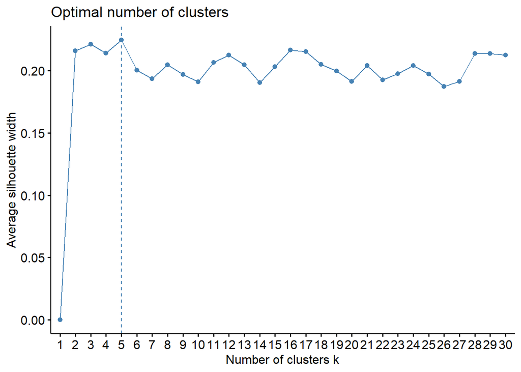

```r
fviz_nbclust(PCApep$x[ ,1:15],kmeans,method = "silhouette", k.max = 30, iter.max=25)
```

## Graficar los datos por medio de heatmap

# Para tener un calculo mas completo, se hacen heatmaps desde 3 clusters hasta 11 clusters y se evaluará el heatmap de 11 clusters

# Heatmap de 3 clusters

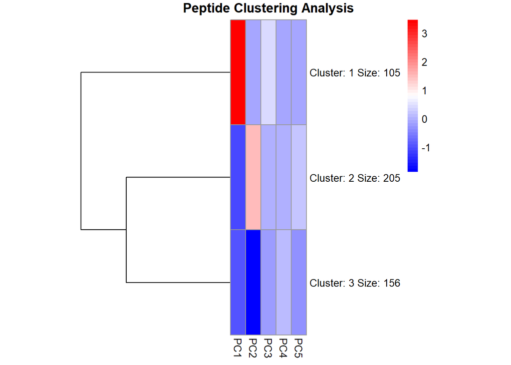

```r
cluster3pep= pheatmap(PCApep$x[,1:5], kmeans_k = 3,cluster_cols = FALSE, treeheight_row = 150, cellwidth = 15, color = colorRampPalette(c("blue", "white", "red"))(50),main = "Peptide Clustering Analysis" )
```

```r
write.csv2 (cluster3pep$kmeans$cluster, file="clustermember3pep.csv")
```

# Heatmap de 4 clusters

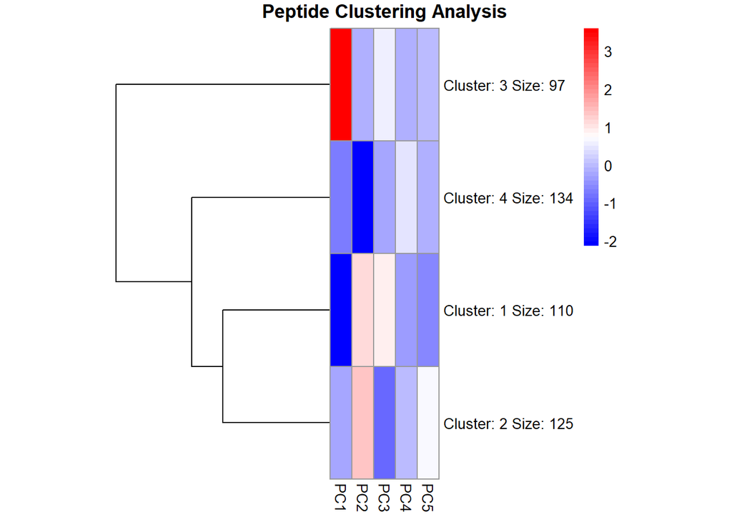

```r
cluster4pep= pheatmap(PCApep$x[,1:5], kmeans_k = 4,cluster_cols = FALSE, treeheight_row = 150, cellwidth = 15, color = colorRampPalette(c("blue", "white", "red"))(50),main = "Peptide Clustering Analysis" )
```

```r
write.csv2 (cluster4pep$kmeans$cluster, file="clustermember4pep.csv")
```

# Heatmap de 5 clusters

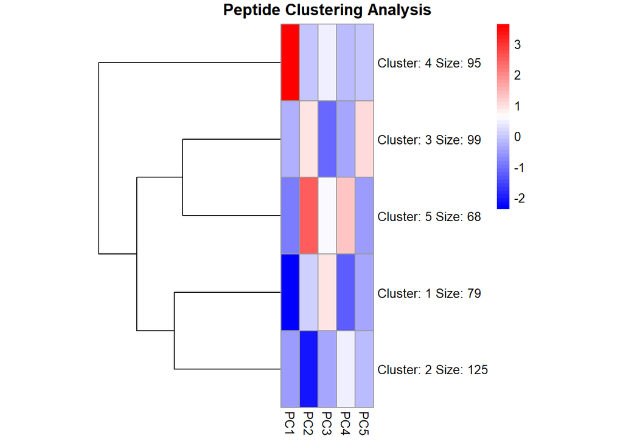

```r
cluster5pep= pheatmap(PCApep$x[,1:5], kmeans_k = 5,cluster_cols = FALSE, treeheight_row = 150, cellwidth = 15, color = colorRampPalette(c("blue", "white", "red"))(50),main = "Peptide Clustering Analysis" )
```

```r
write.csv2 (cluster5pep$kmeans$cluster, file="clustermember5pep.csv")
```

# Heatmap de 6 clusters

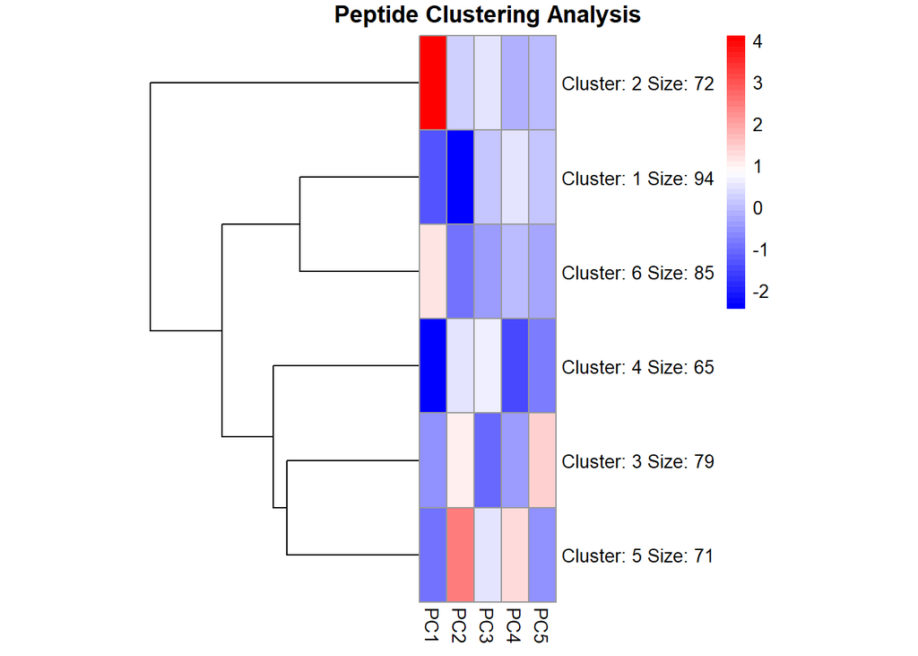

```r
cluster6pep= pheatmap(PCApep$x[,1:5], kmeans_k = 6,cluster_cols = FALSE, treeheight_row = 150, cellwidth = 15, color = colorRampPalette(c("blue", "white", "red"))(50),main = "Peptide Clustering Analysis" )
```

```r
write.csv2 (cluster6pep$kmeans$cluster, file="clustermember6pep.csv")
```

# Heatmap de 7 clusters

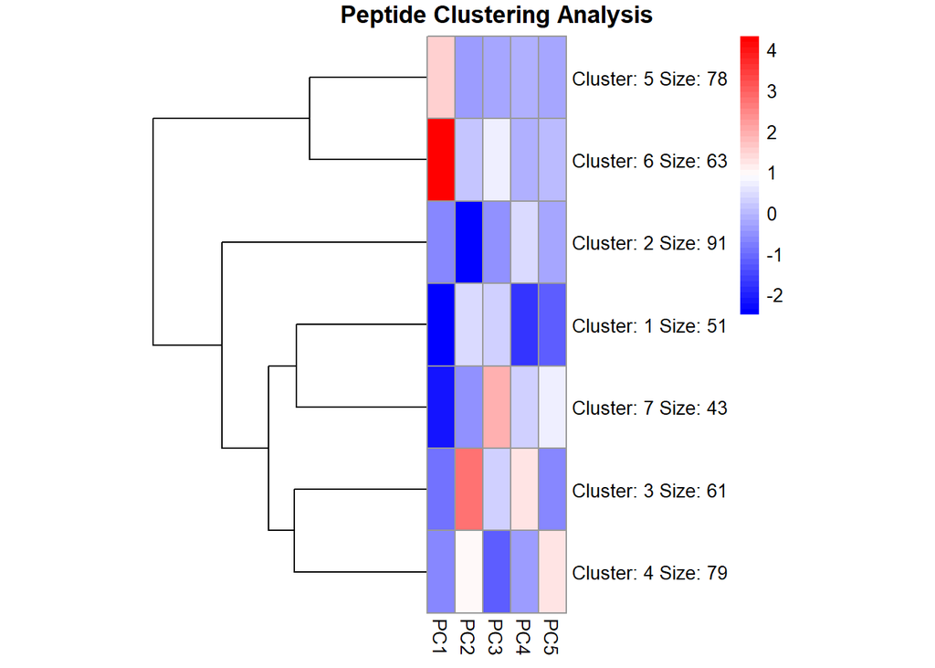

```r
cluster7pep= pheatmap(PCApep$x[,1:5], kmeans_k = 7,cluster_cols = FALSE, treeheight_row = 150, cellwidth = 15, color = colorRampPalette(c("blue", "white", "red"))(50),main = "Peptide Clustering Analysis" )
```

```r
write.csv2 (cluster7pep$kmeans$cluster, file="clustermember7pep.csv")
```

# Heatmap de 8 clusters

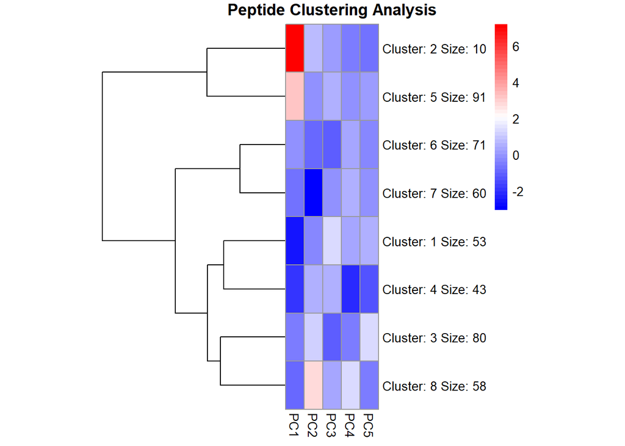

```r
cluster8pep= pheatmap(PCApep$x[,1:5], kmeans_k = 8,cluster_cols = FALSE, treeheight_row = 150, cellwidth = 15, color = colorRampPalette(c("blue", "white", "red"))(50),main = "Peptide Clustering Analysis" )
```

```r
write.csv2 (cluster8pep$kmeans$cluster, file="clustermember8pep.csv")
```

# Heatmap de 9 clusters

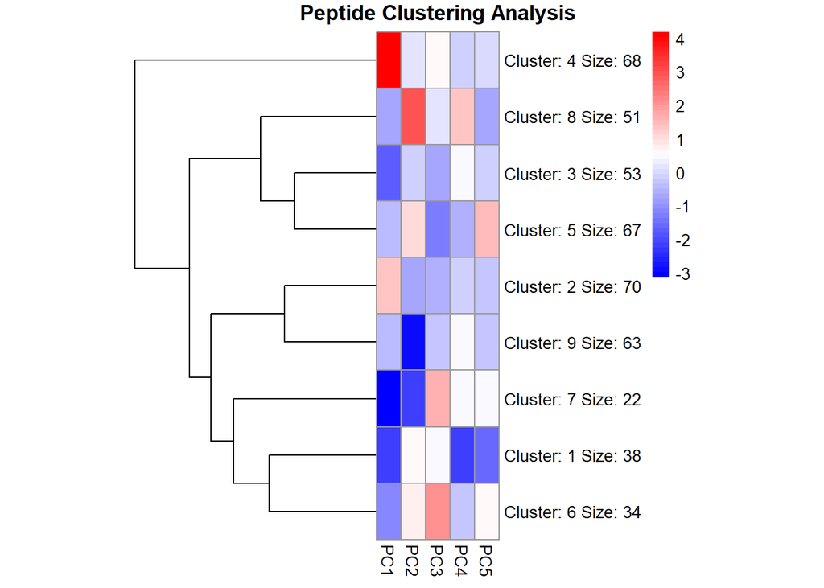

```r
cluster9pep= pheatmap(PCApep$x[,1:5], kmeans_k = 9,cluster_cols = FALSE, treeheight_row = 150, cellwidth = 15, color = colorRampPalette(c("blue", "white", "red"))(50),main = "Peptide Clustering Analysis" )
```

```r
write.csv2 (cluster9pep$kmeans$cluster, file="clustermember9pep.csv")
```

# Heatmap de 10 clusters

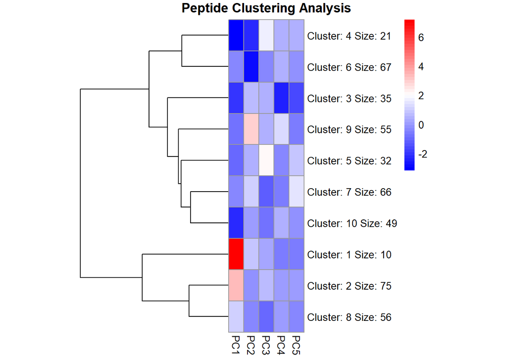

```r
cluster10pep= pheatmap(PCApep$x[,1:5], kmeans_k = 10,cluster_cols = FALSE, treeheight_row = 150, cellwidth = 15, color = colorRampPalette(c("blue", "white", "red"))(50),main = "Peptide Clustering Analysis" )
```

```r
write.csv2 (cluster10pep$kmeans$cluster, file="clustermember10pep.csv")
```

# Heatmap de 11 clusters

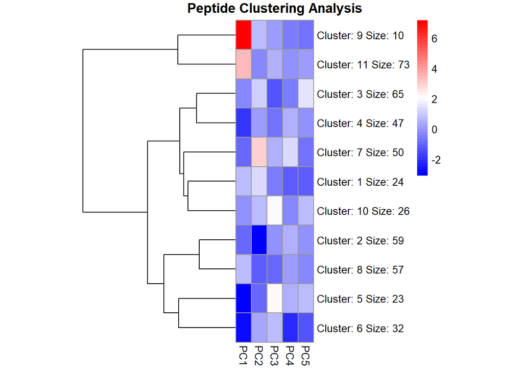

```r
cluster11pep= pheatmap(PCApep$x[,1:5], kmeans_k = 11,cluster_cols = FALSE, treeheight_row = 150, cellwidth = 15, color = colorRampPalette(c("blue", "white", "red"))(50),main = "Peptide Clustering Analysis" )
```

```r
write.csv2 (cluster11pep$kmeans$cluster, file="clustermember11pep.csv")
```

## Análisis de resultados tomados del heatmap de 11 clusters

El primer set de resultados mostró que la mayor concentración de CSP-EX se encuentran en el cluster 7, junto con 27% de los péptidos antioxidantes lo que puede indicar que estos péptidos pueden tener potencial antioxidante.

En el cluster 7 el componente principal 2 es el predominante, los descriptores más sobresalientes son los vectores de Fasgai relacionados con los índices alifático y de hidrofobicidad y el punto isoeléctrico. Lo que significa que este cluster puede estar definido por la interacción con hidrógeno. Cluster 4 tiene 51% de los péptidos con actividad anticongelante, los péptidos CSP-EX en este cluster pueden tener potencial como péptidos anticongelantes.

Cabe resaltar que los péptidos penetrantes de células (CPP) no mostraron una agrupación muy fuerte con los CSP-EX.

## Hipotesís, sobre los datos de estudio

Como el objetivo de estos datos es hacer un análisis de agrupamiento, es nesesario ver si estos datos contienen la suficiente diferencia para poder ser agrupados, es decir, si los centroides de los conjuntos podran diferir entre si. Es por esto que nuestra hipotesís se basará en el calculo de permanova cuyas hipotesís son:

H0= No existe diferencia entre los grupos.

H1= Al menos dos grupos son diferentes.

## Análisis de Datos y componentes principales obtenidos

# Análisis permanova

Segun la documentación, los metodos de análisis no son confiables con datos negativos, por lo que se escogieron metodos que permitian entregar valores aunque el grupo contara con elementos negativos y se escogieron 3 metodos distintos para tener varios analisis y asi poder reforsar lo que se pueda encontrar

```r
DescriptorDF <- as.data.frame(Descriptors[,2:15])
row.names(DescriptorDF) <- peptideDescriptors$Name
head(DescriptorDF)
```

```
##              aIndex     Boman     Charge         PP1        PP2         PP3
## >Antiox_1 103.33333 0.5627778 -1.0538969 -0.33000000 -0.4538889  0.09277778
## >Antiox_2  37.69231 1.9584615  1.3324165 -0.08769231 -0.3384615  0.27615385
## >Antiox_3  14.28571 3.9257143 -4.0497356  0.33714286 -0.4642857 -0.56142857
## >Antiox_6  97.50000 0.7975000  1.9364036 -0.13250000 -0.0993750  0.08625000
## >Antiox_8  20.00000 2.6960000  0.3423275  0.23800000 -0.4880000  0.39800000
## >Antiox_9  55.71429 2.1071429  0.9397985 -0.24142857 -0.1771429  0.06285714
##                   F1         F2          F3          F4          F5         F6
## >Antiox_1 -0.1120556  0.0165000 -0.38272222  0.80944444 0.148000000 -0.2091667
## >Antiox_2 -0.1028462 -0.4549231 -0.43461538 -0.01492308 0.006769231 -0.1303077
## >Antiox_3 -0.7451429  0.2350000 -0.21242857  0.17771429 0.584000000 -1.0128571
## >Antiox_6 -0.0538125 -0.2690625  0.36400000  0.27043750 0.258812500  0.2653125
## >Antiox_8 -0.1720000  0.0892000 -0.54920000 -0.10080000 0.043400000  0.0494000
## >Antiox_9 -0.5312857 -0.4012857  0.01671429  0.12785714 0.943000000  0.2348571
##           Hidrophobicity       pI
## >Antiox_1    -0.02222222 4.258141
## >Antiox_2    -0.07538462 8.564801
## >Antiox_3     0.39142857 3.331708
## >Antiox_6    -0.09625000 9.634027
## >Antiox_8     0.26800000 7.714355
## >Antiox_9     0.03428571 9.348818
```

```r
DescriptorAdo1 <- adonis2(DescriptorDF ~ Tipo, method = "chord", data=peptideDescriptors, permutations=999)
DescriptorAdo2 <- adonis2(DescriptorDF ~ Tipo, method = "euclidean", data=peptideDescriptors, permutations=999)
DescriptorAdo3 <- adonis2(DescriptorDF ~ Tipo, method = "manhattan", data=peptideDescriptors, permutations=999)

DescriptorAdo1
```

```
## Permutation test for adonis under reduced model
## Terms added sequentially (first to last)
## Permutation: free
## Number of permutations: 999
##
## adonis2(formula = DescriptorDF ~ Tipo, data = peptideDescriptors, permutations = 999, method = "chord")
##           Df SumOfSqs      R2      F Pr(>F)
## Tipo       6    4.857 0.06696 5.4905  0.002 **
## Residual 459   67.671 0.93304
## Total    465   72.528 1.00000
## ---
## Signif. codes:  0 '***' 0.001 '**' 0.01 '*' 0.05 '.' 0.1 ' ' 1
```

```r
DescriptorAdo2
```

```
## Permutation test for adonis under reduced model
## Terms added sequentially (first to last)
## Permutation: free
## Number of permutations: 999
##
## adonis2(formula = DescriptorDF ~ Tipo, data = peptideDescriptors, permutations = 999, method = "euclidean")
##           Df SumOfSqs      R2      F Pr(>F)
## Tipo       6   134529 0.09398 7.9351  0.001 ***
## Residual 459  1296950 0.90602
## Total    465  1431479 1.00000
## ---
## Signif. codes:  0 '***' 0.001 '**' 0.01 '*' 0.05 '.' 0.1 ' ' 1
```

```r
DescriptorAdo3
```

```
## Permutation test for adonis under reduced model
## Terms added sequentially (first to last)
## Permutation: free
## Number of permutations: 999
##
## adonis2(formula = DescriptorDF ~ Tipo, data = peptideDescriptors, permutations = 999, method = "manhattan")
##           Df SumOfSqs      R2      F Pr(>F)
## Tipo       6   241489 0.12819 11.249  0.001 ***
## Residual 459  1642299 0.87181
## Total    465  1883788 1.00000
## ---
## Signif. codes:  0 '***' 0.001 '**' 0.01 '*' 0.05 '.' 0.1 ' ' 1
```

## Grafica de correlación, los datos son divididos para ver mejor la grafica, pero son usados todos juntos en la matris de correlación

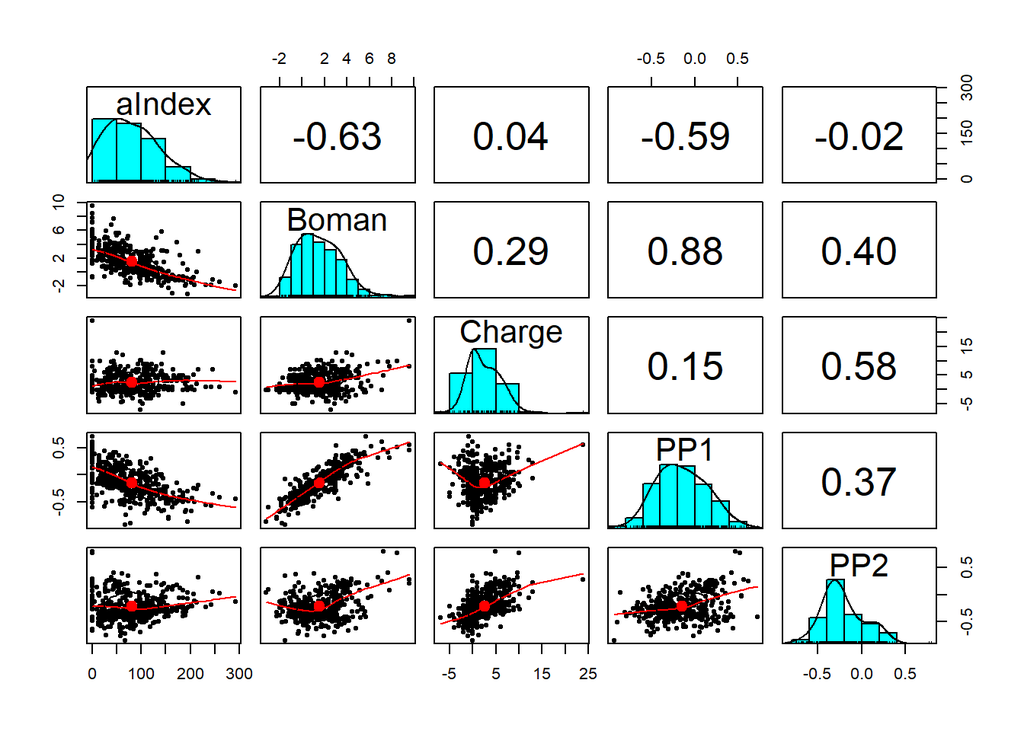

```r
pairs.panels(peptideDescriptors[5:9])
```

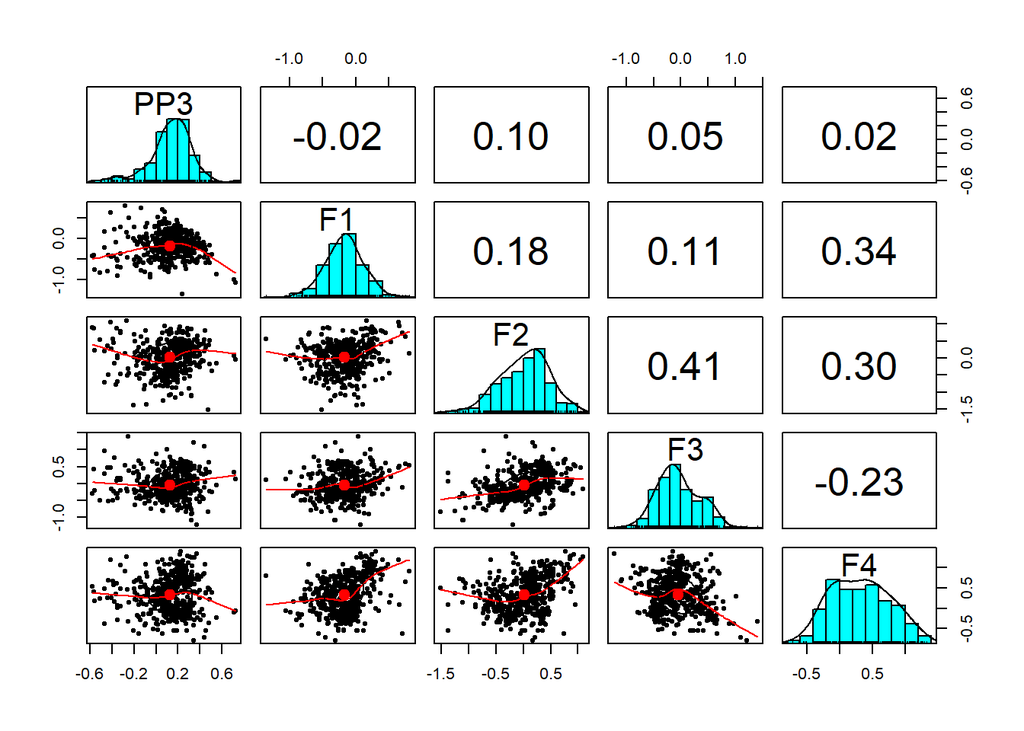

```r
pairs.panels(peptideDescriptors[10:14])
```

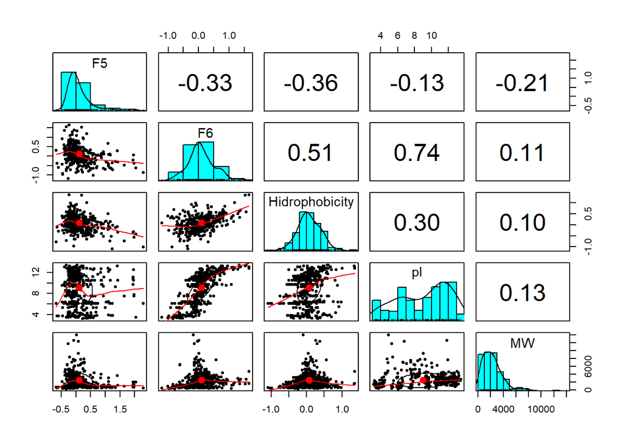

```r
pairs.panels(peptideDescriptors[15:19])
```

```r
DescriptoresCor<-cor(peptideDescriptors[5:19], method = "pearson")
DescriptoresCor
```

```
##                     aIndex       Boman      Charge         PP1         PP2
## aIndex          1.00000000 -0.63424983  0.03964508 -0.59008757 -0.01538146
## Boman          -0.63424983  1.00000000  0.29478238  0.87710305  0.39543574
## Charge          0.03964508  0.29478238  1.00000000  0.15275530  0.57598459
## PP1            -0.59008757  0.87710305  0.15275530  1.00000000  0.36835364
## PP2            -0.01538146  0.39543574  0.57598459  0.36835364  1.00000000
## PP3            -0.04194172  0.24426391  0.72819192  0.03194571  0.28945284
## F1              0.50257400 -0.63413303 -0.03005140 -0.58226077  0.05484521
## F2              0.51515236 -0.02403108  0.26727877  0.09810552  0.33614013
## F3              0.15630353  0.21000815  0.42061741  0.30345046  0.93036679
## F4              0.76435245 -0.62590952 -0.06064807 -0.65609233 -0.38366967
## F5              0.06774276 -0.19537344 -0.24816290 -0.35280510 -0.11579794
## F6             -0.01863411  0.50650754  0.73187305  0.39286036  0.76187271
## Hidrophobicity -0.38279792  0.83170030  0.38488362  0.78016019  0.21625053
## pI              0.13911597  0.21391926  0.84033166  0.04271785  0.61010007
## MW             -0.07234961  0.04850901  0.23475542  0.03880881 -0.10017174
##                        PP3          F1           F2          F3          F4
## aIndex         -0.04194172  0.50257400  0.515152364  0.15630353  0.76435245
## Boman           0.24426391 -0.63413303 -0.024031082  0.21000815 -0.62590952
## Charge          0.72819192 -0.03005140  0.267278770  0.42061741 -0.06064807
## PP1             0.03194571 -0.58226077  0.098105520  0.30345046 -0.65609233
## PP2             0.28945284  0.05484521  0.336140129  0.93036679 -0.38366967
## PP3             1.00000000 -0.01784492  0.103858345  0.05145631  0.02051235
## F1             -0.01784492  1.00000000  0.182042182  0.11132657  0.34004452
## F2              0.10385835  0.18204218  1.000000000  0.40967819  0.30266734
## F3              0.05145631  0.11132657  0.409678191  1.00000000 -0.23410563
## F4              0.02051235  0.34004452  0.302667340 -0.23410563  1.00000000
## F5             -0.27349735 -0.03284154 -0.336981307 -0.10560701  0.10030564
## F6              0.67915146 -0.14628232  0.352733220  0.60253568 -0.31348875
## Hidrophobicity  0.38315327 -0.69790014  0.252897949  0.09464206 -0.26674603
## pI              0.75186317  0.03885569  0.289365871  0.46416175  0.02015822
## MW              0.19508237  0.00733262 -0.009643591 -0.18220143 -0.08672962
##                         F5          F6 Hidrophobicity          pI           MW
## aIndex          0.06774276 -0.01863411    -0.38279792  0.13911597 -0.072349606
## Boman          -0.19537344  0.50650754     0.83170030  0.21391926  0.048509006
## Charge         -0.24816290  0.73187305     0.38488362  0.84033166  0.234755424
## PP1            -0.35280510  0.39286036     0.78016019  0.04271785  0.038808810
## PP2            -0.11579794  0.76187271     0.21625053  0.61010007 -0.100171742
## PP3            -0.27349735  0.67915146     0.38315327  0.75186317  0.195082373
## F1             -0.03284154 -0.14628232    -0.69790014  0.03885569  0.007332620
## F2             -0.33698131  0.35273322     0.25289795  0.28936587 -0.009643591
## F3             -0.10560701  0.60253568     0.09464206  0.46416175 -0.182201431
## F4              0.10030564 -0.31348875    -0.26674603  0.02015822 -0.086729624
## F5              1.00000000 -0.33154869    -0.36375237 -0.13038116 -0.211033738
## F6             -0.33154869  1.00000000     0.51321787  0.73606296  0.110767424
## Hidrophobicity -0.36375237  0.51321787     1.00000000  0.30475983  0.099875457
## pI             -0.13038116  0.73606296     0.30475983  1.00000000  0.125316948
## MW             -0.21103374  0.11076742     0.09987546  0.12531695  1.000000000
```

## Análisis de componentes principales y obtencion de la varianza

```r
DescriptoresDF <- as.data.frame(peptideDescriptors[,5:19])
row.names(DescriptoresDF) <- peptideDescriptors$Name
head(DescriptoresDF)
```

```
##              aIndex     Boman     Charge         PP1        PP2         PP3
## >Antiox_1 103.33333 0.5627778 -1.0538969 -0.33000000 -0.4538889  0.09277778
## >Antiox_2  37.69231 1.9584615  1.3324165 -0.08769231 -0.3384615  0.27615385
## >Antiox_3  14.28571 3.9257143 -4.0497356  0.33714286 -0.4642857 -0.56142857
## >Antiox_6  97.50000 0.7975000  1.9364036 -0.13250000 -0.0993750  0.08625000
## >Antiox_8  20.00000 2.6960000  0.3423275  0.23800000 -0.4880000  0.39800000
## >Antiox_9  55.71429 2.1071429  0.9397985 -0.24142857 -0.1771429  0.06285714
##                   F1         F2          F3          F4          F5         F6
## >Antiox_1 -0.1120556  0.0165000 -0.38272222  0.80944444 0.148000000 -0.2091667
## >Antiox_2 -0.1028462 -0.4549231 -0.43461538 -0.01492308 0.006769231 -0.1303077
## >Antiox_3 -0.7451429  0.2350000 -0.21242857  0.17771429 0.584000000 -1.0128571
## >Antiox_6 -0.0538125 -0.2690625  0.36400000  0.27043750 0.258812500  0.2653125
## >Antiox_8 -0.1720000  0.0892000 -0.54920000 -0.10080000 0.043400000  0.0494000
## >Antiox_9 -0.5312857 -0.4012857  0.01671429  0.12785714 0.943000000  0.2348571
##           Hidrophobicity       pI        MW
## >Antiox_1    -0.02222222 4.258141 1805.0177
## >Antiox_2    -0.07538462 8.564801 1421.5558
## >Antiox_3     0.39142857 3.331708  851.8218
## >Antiox_6    -0.09625000 9.634027 1961.2909
## >Antiox_8     0.26800000 7.714355  551.5595
## >Antiox_9     0.03428571 9.348818  829.9542
```

```r
get_eigenvalue(PCApep)
```

```
##         eigenvalue variance.percent cumulative.variance.percent
## Dim.1  5.569150875      34.80719297                    34.80719
## Dim.2  3.513394951      21.95871845                    56.76591
## Dim.3  1.783756116      11.14847572                    67.91439
## Dim.4  1.408077079       8.80048174                    76.71487
## Dim.5  1.090281193       6.81425746                    83.52913
## Dim.6  0.809205007       5.05753129                    88.58666
## Dim.7  0.631205603       3.94503502                    92.53169
## Dim.8  0.317820987       1.98638117                    94.51807
## Dim.9  0.263097427       1.64435892                    96.16243
## Dim.10 0.211166290       1.31978931                    97.48222
## Dim.11 0.143485248       0.89678280                    98.37900
## Dim.12 0.114231650       0.71394782                    99.09295
## Dim.13 0.075838822       0.47399264                    99.56695
## Dim.14 0.040354572       0.25221608                    99.81916
## Dim.15 0.021229152       0.13268220                    99.95184
## Dim.16 0.007705026       0.04815641                   100.00000
```

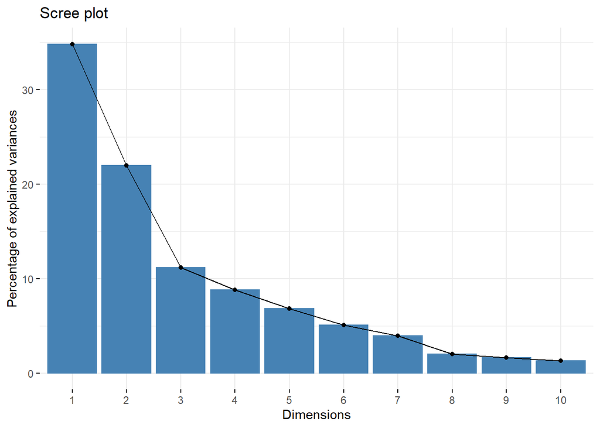

```r
fviz_eig(PCApep)
```

```r
fviz_pca
```

```
## function (X, ...)
## {
##     fviz_pca_biplot(X, ...)
## }
## <bytecode: 0x0000023b0e61e568>
## <environment: namespace:factoextra>
```

## Graficas de distribución con y sin elipses

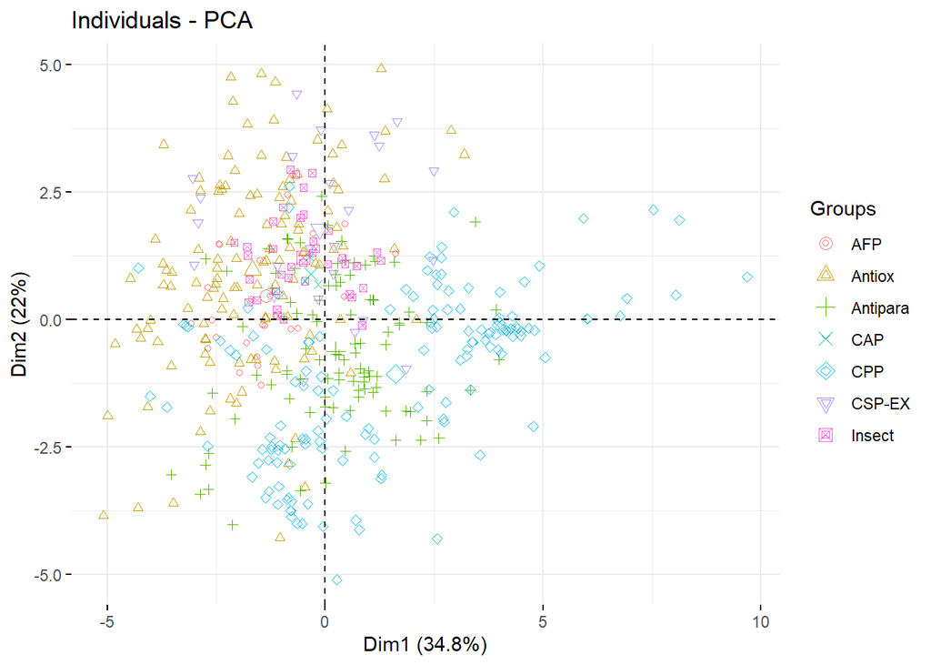

```r
fviz_pca_ind(PCApep, repel = TRUE,
             label = "none",
             habillage = peptideDescriptors$Tipo)
```

```
## Too few points to calculate an ellipse
```

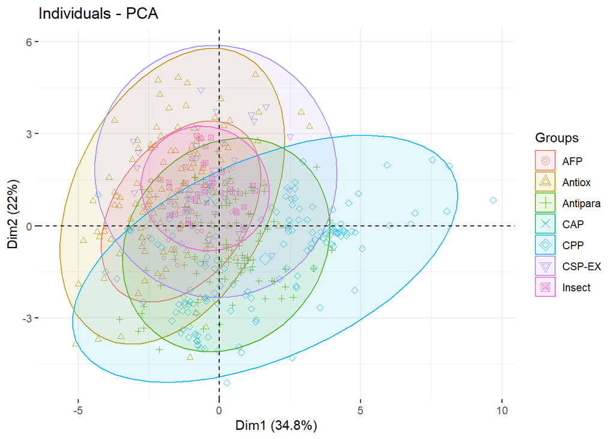

```r
fviz_pca_ind(PCApep, repel = TRUE,
             label = "none",
             habillage = peptideDescriptors$Tipo,
             addEllipses = TRUE)
```

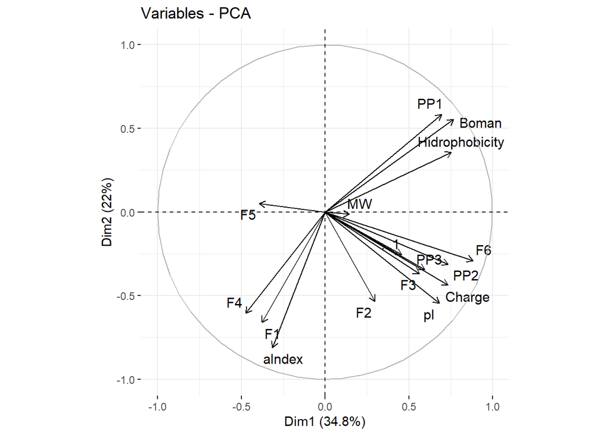

```r
fviz_pca_var(PCApep, repel = TRUE)
```

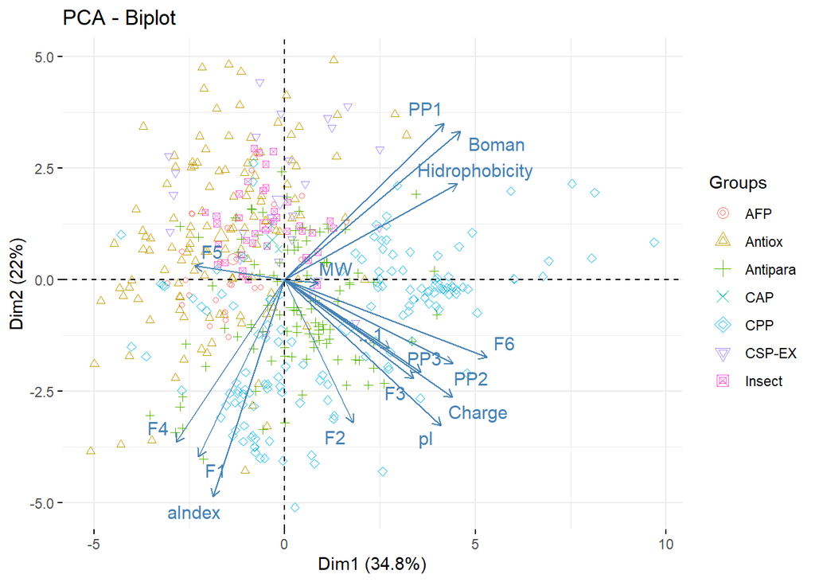

```r
# Ambos

fviz_pca_biplot(PCApep,
                repel = TRUE,
                label = "var",
                habillage = peptideDescriptors$Tipo)
```

## Evaluación

Segun lo encontrado por los tres metodos distintos podemos rechazar H0 y determinar que existe algun grado de diferencia que permitiria la agrupacion.

Según lo observado con los heatmaps, la agrupación de los datos permite un cierto grado de dicernimiento entre los grupos y nos indica un camino a seguir para refinar nuestro análisis, esto sumado a lo observado con el análisis de componentes principales, nos lleva a decir que podriamos cambiar algunos de los descriptores seleccionados, 3 de los 4 cuadrantes del grafico se encuentran bien poblados, mientras que el cuadrante restante solo contiene a la flexibilidad local de los vectores de Fasgai, esto junto al posicionamiento de los descriptores en los otros cuadrantes (siendo estos muy cercanos entre si, con poca dispersion dentro del grafico) nos da la confianza de buscar nuevos descriptores para agregar o reemplazar a los ya existentes.

Existen formas de encontrar los elementos especificos que producen valores atipicos, los pruebas estadisticas de Grubb, Dixon y Rosner nos pueden ayudar a obtener esa informacion, sin embargo para estos datos en particular, los elementos son dificiles de obtener, por lo que resulta mas probechoso cambiar los descriptores que eliminar peptidos, por esto y por lo explicado anterirormente, se determina que una busqueda de otros descriptores permitira tener un mejor set de datos y un mejor mejor set de variables para el agrupamiento, estos datos preliminares nos dan luz sobre que podemos cambiar o de que podemos precindir, lo cual ayudara en gran manera a nuestro trabajo.